# R Notebook: Gibbs Sampling and GAM

# MCMC for Bayesian Inference

## Recap

Posterior predictive distribution:
$$\textrm{Pr} (z^{\textrm{new}}|\boldsymbol{Z})=\int \textrm{Pr} (z^{\textrm{new}}|\theta) \textrm{Pr} (\theta|\boldsymbol{Z}) d\theta$$

Monte Carlo method:
$$\int \textrm{Pr} (z^{\textrm{new}}|\theta) \textrm{Pr} (\theta|\boldsymbol{Z}) d\theta \simeq \frac{1}{n} \sum_{i=1}^n \textrm{Pr} (z^{\textrm{new}}|\theta^{(i)}),$$
where $\theta^{(i)}$ are samples from the posterior $\textrm{Pr} (\theta|\boldsymbol{Z})$.

MCMC (Gibbs sampling):

The Gibbs sampler draws iteratively from posterior conditional distributions rather than drawing directly from the joint posterior distribution. This makes the Gibbs Sampler particularly useful, as the joint posterior is not always easy to work with.

## Gibbs Sampling

The Gibbs sampler works by restructuring the joint estimation problem as a series of smaller, easier estimation problems. To illustrate, let $\theta_1$ and $\theta_2$ be bivariate normally distributed random variables with population mean zero ($\mu_1 = \mu_2 = 0$), unit variance ($\sigma_1^2 = \sigma_2^2 = 1$), and correlation $\rho$.

The Gibbs sampler makes it so that if we sample repeatedly from two conditional distributions. Then these will be samples from the joint distribution $p(\theta_1, \theta_2)$ and its marginals.

```r
sample_bivariate_normal <- function(rho, nr_samples) {
  theta <- matrix(0, nrow = nr_samples, ncol = 2)

  for (i in seq(2, nr_samples)) {
    theta[i, 1] <- rnorm(1, rho*theta[i-1, 2], sqrt(1 - rho^2))  # sample from p(theta1 | theta2)
    theta[i, 2] <- rnorm(1, rho*theta[i, 1]  , sqrt(1 - rho^2))  # sample from p(theta2 | theta1)
  }

  theta
}

set.seed(1)
samples <- sample_bivariate_normal(rho = 0.5, nr_samples = 10000)
cov(samples)
```

```
##           [,1]      [,2]
## [1,] 1.0178545 0.5091747
## [2,] 0.5091747 0.9949518
```

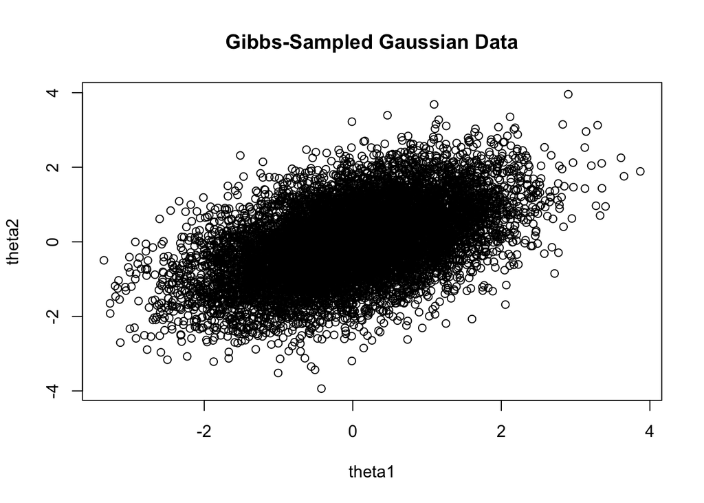

```r
plot(samples,main="Gibbs-Sampled Gaussian Data",xlab="theta1", ylab = "theta2")
```

# Generalized Additive Model in R

GAM:
$$\textrm{E}(Y|X_1,\cdots,X_p)=\alpha_1+f_1(X_1)+\cdots+f_p(X_p).$$

We study the relationship between atmospheric ozone concentration ($O_3$) and other meteorological variables in the Los Angeles Basin in 1976. To simplify matters, let us only focus on three predictors: temperature measured at El Monte (temp), inversion base height at LAX (ibh), and inversion top temperature at LAX (ibt).

```r
# Fit a linear regression model first.

library(faraway)
data(ozone)
olm=lm(O3~temp+ibh+ibt, ozone)
summary(olm)
```

```
##
## Call:
## lm(formula = O3 ~ temp + ibh + ibt, data = ozone)
##
## Residuals:
##      Min       1Q   Median       3Q      Max
## -11.3224  -3.1913  -0.2591   2.9635  13.2860
##
## Coefficients:
##               Estimate Std. Error t value Pr(>|t|)
## (Intercept) -7.7279822  1.6216623  -4.765 2.84e-06 ***
## temp         0.3804408  0.0401582   9.474  < 2e-16 ***
## ibh         -0.0011862  0.0002567  -4.621 5.52e-06 ***
## ibt         -0.0058215  0.0101793  -0.572    0.568
## ---
## Signif. codes:  0 '***' 0.001 '**' 0.01 '*' 0.05 '.' 0.1 ' ' 1
##
## Residual standard error: 4.748 on 326 degrees of freedom
## Multiple R-squared:  0.652,  Adjusted R-squared:  0.6488
## F-statistic: 203.6 on 3 and 326 DF,  p-value: < 2.2e-16
```

Note that ibt is not significant in this model. One task among others in a regression analysis is to find the right transformation on the predictors. Additive models can help here.

Now we fit an additive model using the Gaussian response as the default. We use the loess smoother by specifying lo in the model formula for all three predictors.

```r
library(gam)
amgam=gam(O3~lo(temp)+lo(ibh)+lo(ibt), data=ozone)
summary(amgam)
```

```
##
## Call: gam(formula = O3 ~ lo(temp) + lo(ibh) + lo(ibt), data = ozone)
## Deviance Residuals:
##      Min       1Q   Median       3Q      Max
## -13.1146  -2.3624  -0.2092   2.1732  12.4447
##
## (Dispersion Parameter for gaussian family taken to be 18.6638)
##
##     Null Deviance: 21115.41 on 329 degrees of freedom
## Residual Deviance: 5935.096 on 318.0005 degrees of freedom
## AIC: 1916.049
##
## Number of Local Scoring Iterations: NA
##
## Anova for Parametric Effects
##            Df  Sum Sq Mean Sq  F value    Pr(>F)
## lo(temp)    1 11958.2 11958.2 640.7153 < 2.2e-16 ***
## lo(ibh)     1  1117.3  1117.3  59.8646 1.358e-13 ***
## lo(ibt)     1     3.5     3.5   0.1898    0.6634
## Residuals 318  5935.1    18.7
## ---
## Signif. codes:  0 '***' 0.001 '**' 0.01 '*' 0.05 '.' 0.1 ' ' 1
##
## Anova for Nonparametric Effects
##             Npar Df Npar F     Pr(F)
## (Intercept)
## lo(temp)        2.5 7.4550 0.0002456 ***
## lo(ibh)         2.9 7.6205 8.243e-05 ***
## lo(ibt)         2.7 7.8434 9.917e-05 ***
## ---
## Signif. codes:  0 '***' 0.001 '**' 0.01 '*' 0.05 '.' 0.1 ' ' 1
```

Compared to the linear model, the $R^2$ of GAM is improved by more than 10%. However, the **loess** fit does use more degrees of freedom (i.e. the effective number of parameters is estimated by the trace of the projection matrix). The **gam** package uses a score test for testing the significance for each predictor. But the p-values are only approximate at best and should be viewed with some skepticism. It is generally better to fit the model without the predictor of interest and then construct the F-test.

```r
amgamr=gam(O3~lo(temp)+lo(ibh), data = ozone)
anova(amgamr, amgam, test="F")
```

|  | Resid. Df | Resid. Dev | Df | Deviance | F | Pr(>F) |
| --- | --- | --- | --- | --- | --- | --- |
| 1 | 321.6653 | 6044.567 | NA | NA | NA | NA |
| 2 | 318.0005 | 5935.096 | 3.664772 | 109.4714 | 1.600493 | 0.1790025 |

Although the p-value from F-test is still an approximation, we can see some evidence that ibt is not significant. Let us examine the fit for all three variables.

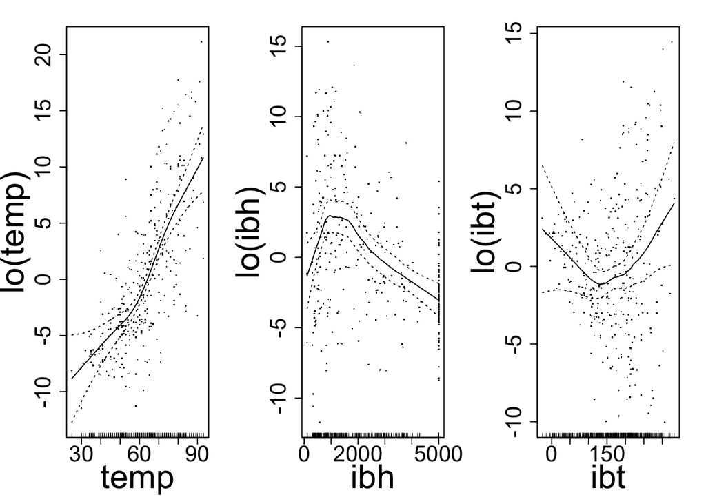

```r
par(mfrow=c(1,3), mar=c(5,5,2,2), cex.lab=3, cex.axis=2)
plot(amgam, residuals=TRUE, se=TRUE, pch=".")
```

For the **ibt**, the confidence band can hold a constant function, which reinforces the conclusion that it is not significant. For variable **temp**, it is clear that an “elbow” around 60 degree, while for **ibh**, it reaches maximum around 1000.

Another method of fitting GAM is **mgcv** package. Although splines are the only choice of smoother in the **mgcv** package, it has an automatic choice in the amount of smoothing as well as wider functionality.

```r
library(mgcv)
ammgcv=gam(O3~s(temp)+s(ibh)+s(ibt), data=ozone)
summary(ammgcv)
```

```
##
## Family: gaussian
## Link function: identity
##
## Formula:
## O3 ~ s(temp) + s(ibh) + s(ibt)
##
## Parametric coefficients:
##             Estimate Std. Error t value Pr(>|t|)
## (Intercept)  11.7758     0.2382   49.44   <2e-16 ***
## ---
## Signif. codes:  0 '***' 0.001 '**' 0.01 '*' 0.05 '.' 0.1 ' ' 1
##
## Approximate significance of smooth terms:
##           edf Ref.df      F  p-value
## s(temp) 3.386  4.259 20.681  < 2e-16 ***
## s(ibh)  4.174  5.076  7.338 1.74e-06 ***
## s(ibt)  2.112  2.731  1.400    0.214
## ---
## Signif. codes:  0 '***' 0.001 '**' 0.01 '*' 0.05 '.' 0.1 ' ' 1
##
## R-sq.(adj) =  0.708   Deviance explained = 71.7%
## GCV = 19.346  Scale est. = 18.72     n = 330
```

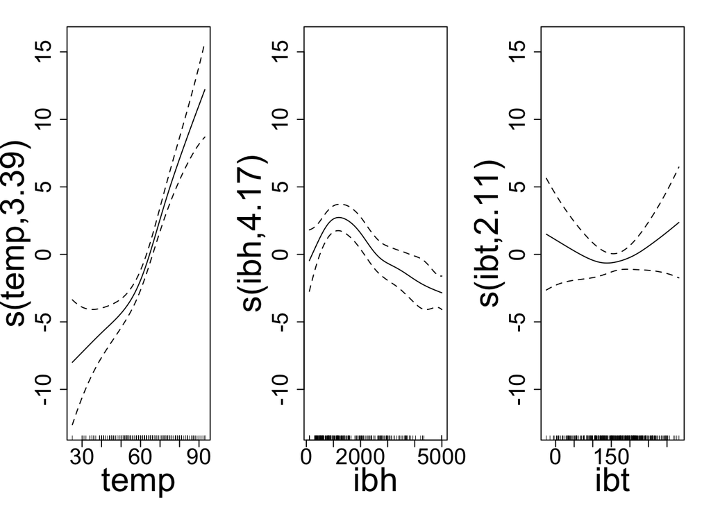

```r
par(mfrow=c(1,3), mar=c(5,5,2,2), cex.lab=3, cex.axis=2)
plot(ammgcv)
```

We see that the $R^2$ is about the same as the **gam** fit. We can also examine the transformation used for each variable. We can see that the fitted transformations are again similar to **gam** fit. Variable **ibt** does not appear to be significant.

We can also test whether there is a nonlinear trend for variables temp by fitting a model with a linear term of **temp** and then make the F-test. The test result confirms that there is really a change in the trend of temperature.

```r
am1=gam(O3~s(temp)+s(ibh),data=ozone)
am2=gam(O3~temp+s(ibh),data=ozone)
anova(am2,am1,test="F")
```

|  | Resid. Df | Resid. Dev | Df | Deviance | F | Pr(>F) |
| --- | --- | --- | --- | --- | --- | --- |
| 1 | 322.7383 | 6949.966 | NA | NA | NA | NA |
| 2 | 319.1147 | 6053.991 | 3.623656 | 895.9755 | 13.10894 | 3.146492e-09 |